# Set up four demographic models for Dicaeum

### 0.1 Installation details and load library

```r
#install devtools
#install.packages("devtools")
#manually install package 'PopGenome' because it's been removed from CRAN
#devtools::install_github("pievos101/PopGenome")
## install  POPdemog to be able to plot your models
#install.packages("https://github.com/YingZhou001/POPdemog/raw/master/POPdemog_1.0.3.tar.gz",repos=NULL)
#install PipeMaster
#devtools::install_github("gehara/PipeMaster")
#load PipeMaster package if install worked
library(PipeMaster)
library(vcfR)
library(SNPfiltR)
```

### 0.2 set up a fresh directory to store the results from this script

```r
#create a new directory to save outputs from the rest of this script
#dir.create("~/Desktop/PM_dicaeum") #this line can be commented once it is run the first time, and the directory is created
#set this new folder as your working directory
setwd("~/Desktop/PM_dicaeum")
```

### 0.3 setup models

```r
#This chunk is set to 'eval=FALSE' because it requires using the interactive function main.menu() to set up the model, which is best done manually directly in the console, rather than during knitting a Qmd.
##running 'm1 <- main.menu()' sets up a model called 'm1'. Do this in the console pane, not directly in the Qmd doc, because it opens an interactive response window that you need to engage with via typing in the console.
##IF you mess up at any time you can hit ctrl-C to exit, and then type 'm1 <- main.menu(m1)', which will take you back to the 'Model Builder' menu for your model. Note that if you error out of the interactive session, your changes will not be saved! The object you created through main.menu() is only updated/saved when you end your interactive Model Builder session by typing 'Q'.

#type 'm1 <- main.menu()'. This will be a 3 species model matching the ASTRAL tree, with non-sister gene flow between Luzon and Mindanao
#then, type '((1,2)3)' to set up a three population bifurcating model (matching this exact newick string is crucial), where:
#pop 3: Luzon
#pop 2: Mindanao
#pop 1: Zamboanga
#and the tree follows the ASTRAL results
#then, type 'I' to enter the 'Gene setup' portion
#type 'genomic', hit enter, then type '2188' to simulate 2188 loci.
#Set mutation rate to a default avian prior (4.6x10e-09) then type 'B' to go back to the main 'Model Builder' menu.

#then, type 'P' to visualize the model you've created and make sure it looks right.

#then, type 'F' to set up migration priors and type 'YES' to set up migration between all pops.

#then, type 'D', and then 'YES' and set up a change in migration between pops 2&3. Then type 'B' to go back to the main menu.

#now type 'H' to set up conditions, and type 'Y' to generate the condition matrices. Then type 'B' to go back to the main menu, and 'Q' to quit and save this model.

#we now have a model named 'm1' that we can manipulate as a typical R object to finish setting up our model.
m1 #see details
#manipulate lower range of Ne prior for each pop so that the prior ranges from 10K-500K
m1$flags$n[c(1:3),4]<- "1e+04"
#remove all migration edges except between lineages 2&3
m1$flags$m<-m1$flags$m[c(4,6),]
#update the # of individuals migrating per gen to 0.1 - 2
m1$flags$m[c(1,2),5]<-"2"
#make migration shift timing minimum prior = 500K
m1$flags$em$time[c(1,2),4]<-"5e+05"
#make migration shift timing maximum prior = 2M
m1$flags$em$time[c(1,2),5]<-"2e+06"
#leave coalescent times minimum priors = 500K
#make coalescent times maximum prior = 2M
m1$flags$ej[c(1,2),5]<-"2e+06"
#remove those extraneous migration edges we deleted above from the conditional migration matrix
m1$conds$mig.matrix<-m1$conds$mig.matrix[c(4,7),c(4,7)]
#make sure the timing of join2_3 is always > the timing of join1_2 (i.e., enforce the topology)
m1$conds$time.matrix[2,1]<-">"
m1$conds$time.matrix[1,2]<-"<"
#enforce the shift in migration rate at the same time as the join between pops 1 and 2 happens:
m1$conds$time.matrix[1,c(3,4)]<-"="
m1$conds$time.matrix[c(3,4),1]<-"="

#check model
m1

#it can be quite tedious to get these models set up exactly correctly, but the code and instructions above are aimed to give you a start. At the end of the day, the four models that I set up for this paper (after a ton of tweaking) look like this:
#read models in if needed
m1<-dget("m1.txt")
m2<-dget("m2.txt")
m3<-dget("m3.txt")
m4<-dget("m4.txt")

#Model 1: ((1,2),3) with non-sister gene flow
$flags
$flags$n
     [,1]       [,2] [,3] [,4]      [,5]    [,6]
[1,] "Ne0.pop1" "-n" "1"  "2.5e+05" "5e+05" "runif"
[2,] "Ne0.pop2" "-n" "2"  "2.5e+05" "5e+05" "runif"
[3,] "Ne0.pop3" "-n" "3"  "2.5e+05" "5e+05" "runif"

$flags$m
     [,1]       [,2] [,3]  [,4]  [,5] [,6]
[1,] "mig0.2_3" "-m" "2 3" "0.1" "2"  "runif"
[2,] "mig0.3_2" "-m" "3 2" "0.1" "2"  "runif"

$flags$em
$flags$em$size
     [,1]       [,2]  [,3]  [,4] [,5] [,6]
[1,] "mig1.2_3" "-em" "2 3" "0"  "0"  "runif"
[2,] "mig1.3_2" "-em" "3 2" "0"  "0"  "runif"

$flags$em$time
     [,1]         [,2]  [,3]  [,4]    [,5]    [,6]
[1,] "t.mig1.2_3" "-em" "2 3" "1e+05" "5e+05" "runif"
[2,] "t.mig1.3_2" "-em" "3 2" "1e+05" "5e+05" "runif"


$flags$ej
     [,1]      [,2]  [,3]  [,4]    [,5]    [,6]
[1,] "join1_2" "-ej" "1 2" "1e+05" "5e+05" "runif"
[2,] "join2_3" "-ej" "2 3" "5e+05" "1e+06" "runif"


$conds
$conds$size.matrix
         Ne0.pop1 Ne0.pop2 Ne0.pop3
Ne0.pop1        0       NA       NA
Ne0.pop2       NA        0       NA
Ne0.pop3       NA       NA        0

$conds$mig.matrix
         mig0.2_3 mig0.3_2
mig0.2_3       NA       NA
mig0.3_2       NA       NA

$conds$time.matrix
           join1_2 join2_3 t.mig1.2_3 t.mig1.3_2
join1_2    "0"     "<"     "="        "="
join2_3    ">"     "0"     ">"        ">"
t.mig1.2_3 "="     "<"     "0"        NA
t.mig1.3_2 "="     "<"     NA         "0"


$tree
[1] "((1,2),3)"

attr(,"class")
[1] "Model"

#Model 2: (1,(2,3)) with non-sister gene flow
$flags
$flags$n
     [,1]       [,2] [,3] [,4]      [,5]    [,6]
[1,] "Ne0.pop1" "-n" "1"  "2.5e+05" "5e+05" "runif"
[2,] "Ne0.pop2" "-n" "2"  "2.5e+05" "5e+05" "runif"
[3,] "Ne0.pop3" "-n" "3"  "2.5e+05" "5e+05" "runif"

$flags$m
     [,1]       [,2] [,3]  [,4]  [,5] [,6]
[1,] "mig0.1_2" "-m" "1 2" "0.1" "2"  "runif"
[2,] "mig0.2_1" "-m" "2 1" "0.1" "2"  "runif"

$flags$ej
     [,1]      [,2]  [,3]  [,4]    [,5]    [,6]
[1,] "join2_3" "-ej" "2 3" "1e+05" "5e+05" "runif"
[2,] "join1_3" "-ej" "1 3" "5e+05" "1e+06" "runif"


$conds
$conds$size.matrix
         Ne0.pop1 Ne0.pop2 Ne0.pop3
Ne0.pop1        0       NA       NA
Ne0.pop2       NA        0       NA
Ne0.pop3       NA       NA        0

$conds$mig.matrix
         mig0.1_2 mig0.2_1
mig0.1_2       NA       NA
mig0.2_1       NA       NA

$conds$time.matrix
        join2_3 join1_3
join2_3 "0"     "<"
join1_3 ">"     "0"


$tree
[1] "(1,(2,3))"

attr(,"class")
[1] "Model"

#Model 3: Trifurcation
$flags
$flags$n
     [,1]       [,2] [,3] [,4]      [,5]    [,6]
[1,] "Ne0.pop1" "-n" "1"  "2.5e+05" "5e+05" "runif"
[2,] "Ne0.pop2" "-n" "2"  "2.5e+05" "5e+05" "runif"
[3,] "Ne0.pop3" "-n" "3"  "2.5e+05" "5e+05" "runif"

$flags$ej
     [,1]      [,2]  [,3]  [,4]    [,5]    [,6]
[1,] "join2_3" "-ej" "2 3" "1e+05" "1e+06" "runif"
[2,] "join1_3" "-ej" "1 3" "1e+05" "1e+06" "runif"


$conds
$conds$size.matrix
         Ne0.pop1 Ne0.pop2 Ne0.pop3
Ne0.pop1        0       NA       NA
Ne0.pop2       NA        0       NA
Ne0.pop3       NA       NA        0

$conds$time.matrix
        join2_3 join1_3
join2_3 "0"     "="
join1_3 "="     "0"


$tree
[1] "(1,(2,3))"

attr(,"class")
[1] "Model"

#Model 4: Trifurcation with gene flow
$flags
$flags$n
     [,1]       [,2] [,3] [,4]      [,5]    [,6]
[1,] "Ne0.pop1" "-n" "1"  "2.5e+05" "5e+05" "runif"
[2,] "Ne0.pop2" "-n" "2"  "2.5e+05" "5e+05" "runif"
[3,] "Ne0.pop3" "-n" "3"  "2.5e+05" "5e+05" "runif"

$flags$m
     [,1]       [,2] [,3]  [,4]  [,5] [,6]
[1,] "mig0.1_2" "-m" "1 2" "0.1" "2"  "runif"
[2,] "mig0.2_1" "-m" "2 1" "0.1" "2"  "runif"
[3,] "mig0.2_3" "-m" "2 3" "0.1" "2"  "runif"
[4,] "mig0.3_2" "-m" "3 2" "0.1" "2"  "runif"

$flags$ej
     [,1]      [,2]  [,3]  [,4]    [,5]    [,6]
[1,] "join2_3" "-ej" "2 3" "1e+05" "1e+06" "runif"
[2,] "join1_3" "-ej" "1 3" "1e+05" "1e+06" "runif"


$conds
$conds$size.matrix
         Ne0.pop1 Ne0.pop2 Ne0.pop3
Ne0.pop1        0       NA       NA
Ne0.pop2       NA        0       NA
Ne0.pop3       NA       NA        0

$conds$mig.matrix
         mig0.1_2 mig0.2_1 mig0.2_3 mig0.3_2
mig0.1_2       NA       NA       NA       NA
mig0.2_1       NA       NA       NA       NA
mig0.2_3       NA       NA       NA       NA
mig0.3_2       NA       NA       NA       NA

$conds$time.matrix
        join2_3 join1_3
join2_3 "0"     "="
join1_3 "="     "0"


$tree
[1] "(1,(2,3))"

attr(,"class")
[1] "Model"
```

### 0.4 prune outgroups from sampling and create Stacks input files needed to generate the 58 sample 2188 locus ingroup alignment needed for PipeMaster input

```r
#read in vcf containing samples and SNPs
vcf<-vcfR::read.vcfR("~/Downloads/filtered.85.unlinked.vcf.gz")
```

```
Scanning file to determine attributes.
File attributes:
  meta lines: 14
  header_line: 15
  variant count: 2590
  column count: 69

Meta line 14 read in.
All meta lines processed.
gt matrix initialized.
Character matrix gt created.
  Character matrix gt rows: 2590
  Character matrix gt cols: 69
  skip: 0
  nrows: 2590
  row_num: 0

Processed variant 1000
Processed variant 2000
Processed variant: 2590
All variants processed
```

```r
vcf
```

```
***** Object of Class vcfR *****
60 samples
2590 CHROMs
2,590 variants
Object size: 12.9 Mb
11.18 percent missing data
*****        *****         *****
```

```
15.52% of SNPs fell below a minor allele count of 1 and were removed from the VCF
```

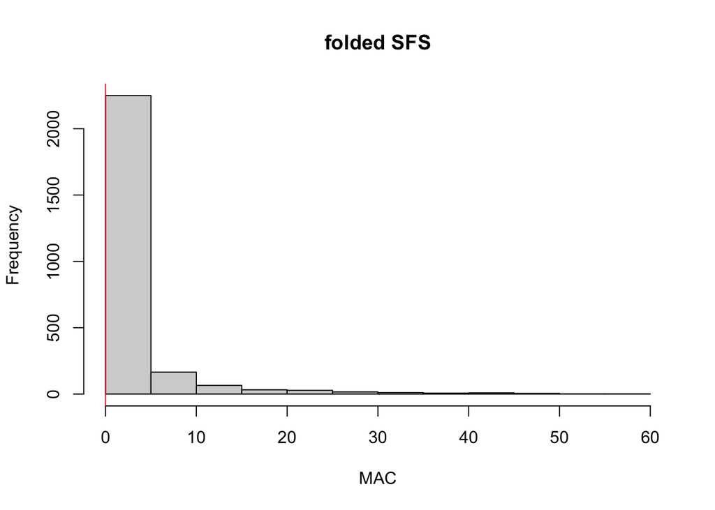

```r
#remove outgroup samples from the vcf
vcf<-vcf[,colnames(vcf@gt) != "D_nigrilore_KU28413" & colnames(vcf@gt) != "D_nigrilore_KU28414"]
#remove sites that are now invariant
vcf<-SNPfiltR::min_mac(vcf,1)
```

```r
vcf
```

```
***** Object of Class vcfR *****
58 samples
2188 CHROMs
2,188 variants
Object size: 10.6 Mb
10.94 percent missing data
*****        *****         *****
```

```r
#make popmap for Stacks
p<-gsub("D_hypoleucum_","hyp",colnames(vcf@gt)[-1])
df<-data.frame(ind=colnames(vcf@gt)[-1],pop=p)
#write out popmap for stacks
#write.table(df, file = "~/Desktop/PM_dicaeum/PM.popmap.txt", quote = F, row.names = F, col.names = F, sep = "\t")
#get a list of just locus names to use as whitelist for stacks
whitelist<-sub(":.*", "", vcf@fix[,1])
#make sure each locus is unique
length(unique(whitelist)) == length(whitelist)
```

```
[1] TRUE
```

```r
#write out whitelist for stacks
#write.table(whitelist, file = "~/Desktop/PM_dicaeum/2188.whitelist.txt", quote = F, row.names = F, col.names = F)
```

copy both of those files you just wrote to you local disk into your project directory on the cluster

### 0.5 Run this bash code on the cluster in a fresh directory where you want output stored, to generate a single fasta alignment for all 2188 loci and all 58 individuals, using Stacks

Important note: You should use the ‘–fasta-samples’ option to ensure that both haplotypes are written out for each sample. This is what the PipeMaster input function is expecting! If you use a consensus fasta for each sample with IUPAC codes, summary statistics will be (silently) calculated incorrectly for your empirical dataset! This is a big deal and this step has to be done right if we want to be able to trust the results at all.

```bash
#run this bash code in a terminal window in the directory where you want the output to be (should be fast enough that you don't need to submit a job), specifying the path to where you ran your optimized Stacks iteration to the -P flag
#(whitelist includes the loci you want to keep and popmap includes the samples you want to keep based on filtering)
#--phylip-var-all flag indicates to output the phylip including invariant sites (best for phylogenetic reconstruction)
/home/d669d153/work/stacks-2.41/populations -P /home/d669d153/work/phil.dicaeum/stacks_n8 -O . -M PM.popmap.txt --whitelist 2188.whitelist.txt --fasta-samples

#annoyingly, Stacks adds a line at the end of the file that says something like '# Stacks v2.41;  Phylip interleaved; December 02, 2022'
#this is not standard for a phylip file, and will cause an error if you try to use this file to build a tree. Luckily, you can use the following sed one-liner below to easily remove this trailing line and write the cleaned output to a new file
sed '/^#/ d' populations.samples.fa > pops.fa
```

### 0.6 read in combined fasta and cut it up into a single fasta alignment for each locus

```r
#read in the fasta file generated in stacks
dna<-read.dna(file = "~/Desktop/PM_dicaeum/populations.samples.fa", format="fasta")
#isolate locus names
list.names<-names(as.character(dna))
#isolate the informative part that identifies the locus
locus.list<-gsub("CLocus","Locus",stringr::str_extract(list.names, "[^_]*_[^_]*"))
#isolate the informative part that identifies the sample
sample.list<-gsub("]","",sub(".*([A-Za-z]+_[A-Za-z])", "\\1", list.names))
#get a list of all unique loci in the order they appear in the fasta file
unique.loci<-unique(locus.list)
#split the dataframe into an individual object for each locus
for (i in 1:length(unique(locus.list))){
  #isolate each sequence associated with the given locus
  locusi<-dna[locus.list == unique(locus.list)[i]]
  #assign informative sample names to each sequence for this given locus
  names(locusi)<-sample.list[locus.list == unique(locus.list)[i]]
  #write that sample to file
  #you will need to change this path to make it point to an empty directory where you want these fastas dumped
  #write.FASTA(x = locusi, file=paste0("~/Desktop/PM_dicaeum/haplotype.fastas/locus.",i,".fasta"))
  print(i)
}

#make sure those files were created in the directory we want them in
list.files(path = "~/Desktop/PM_dicaeum/haplotype.fastas")[1:5] #print first 5 files in this directory
```

### 0.7 match empirical parameters to the models to be simulated

```r
#matching the empirical parameters in the simulated models is done by the function 'get.data.structure()', which takes as input four arguments: model, path.to.fasta, pop.assign, sanger
#'model' just needs the R object describing the model (set up above) passed to it
#'path.to.fasta' needs the path (relative or complete) to a directory full of fastas, which are our empirical input data
#'pop.assign' takes a data.frame object with two columns 'sample' and 'pop'
#'sanger' is looking for a logical statement telling the function whether this is sanger data

#load in sampling info to make object 'popassign'
samp<-read.csv("~/Downloads/dicaeum.retained.sampling.csv")
#remove outgroup samples
samp<-samp[c(1:54,57:60),]
#rename extra long sample name
samp[13,1]<-"m_FMNH454949"
#make sure individual names in dataframe match the fastas
samp$ID %in% unique(sample.list)
#create popassign object
popassign<-data.frame(sample=samp$ID, pop=samp$Taxa)
#assign lineages to numbers based on the model
popassign$pop[popassign$pop == "Luzon"]<-3
popassign$pop[popassign$pop == "Mindanao"]<-2
popassign$pop[popassign$pop == "Zamboanga"]<-1
#convert those numbers to class 'integer'
popassign$pop<-as.integer(popassign$pop)
#make sure that worked
head(popassign)
#write to disk
#write.csv(popassign, "~/Desktop/PM_dicaeum/popassign.csv", row.names=F, quote=F)

#replicate the data structure for model 1
m1 <- get.data.structure(model = m1, path.to.fasta = "/Users/devonderaad/Desktop/PM_dicaeum/haplotype.fastas", pop.assign = popassign, sanger = F)

#repeat for model 2
m2 <- get.data.structure(model = m2, path.to.fasta = "/Users/devonderaad/Desktop/PM_dicaeum/haplotype.fastas", pop.assign = popassign, sanger = F)

#repeat for model 3
m3 <- get.data.structure(model = m3, path.to.fasta = "/Users/devonderaad/Desktop/PM_dicaeum/haplotype.fastas", pop.assign = popassign, sanger = F)

#print model m1 and verify that it has been set up correctly to match empirical details
m1
#plot the model to make sure it's set up correctly
PlotModel(model=m1, use.alpha = F, average.of.priors=F)
#save model m1-m4
#dput(m1, "/Users/devonderaad/Desktop/PM_dicaeum/m1.txt")
#dput(m2, "/Users/devonderaad/Desktop/PM_dicaeum/m2.txt")
#dput(m3, "/Users/devonderaad/Desktop/PM_dicaeum/m3.txt")
#dput(m4, "/Users/devonderaad/Desktop/PM_dicaeum/m4.txt")
```

### 0.8 Calculate empirical summary stats on our dataset and write to disk

```r
m1<-dget("m1.txt")
popassign<-read.csv("~/Desktop/PM_dicaeum/popassign.csv")
#calculate summary stats for empirical data
obs <- obs.sumstat.ngs(model = m1, path.to.fasta = "~/Desktop/PM_dicaeum/haplotype.fastas", pop.assign = popassign)
```

[output not shown]

[output cut: 2173 more lines]

```r
#save this output to file
print(obs)
```

```
         s_average_segs_1 s_variance_segs_1 s_average_segs_2 s_variance_segs_2
observed          1.38574          2.257172         5.457495          11.29266
         s_average_segs_3 s_variance_segs_3 s_average_segs s_variance_segs
observed         3.440128          6.229153       7.712523         15.2255
         s_average_pi_1 s_variance_pi_1 s_average_pi_2 s_variance_pi_2
observed        0.37476       0.2129968       0.678225       0.3885984
         s_average_pi_3 s_variance_pi_3 s_average_pi s_variance_pi
observed      0.6388867       0.3735247    0.6954365     0.3750656
         s_average_w_1 s_variance_w_1 s_average_w_2 s_variance_w_2
observed     0.4431231      0.2315317      1.173904      0.5222348
         s_average_w_3 s_variance_w_3 s_average_w s_variance_w s_average_tajd_1
observed     0.8604295      0.3896446    1.478928    0.5603359       -0.4357214
         s_variance_tajd_1 s_average_tajd_2 s_variance_tajd_2 s_average_tajd_3
observed          0.855465         -1.03903         0.4110414       -0.6830109
         s_variance_tajd_3 s_average_tajd s_variance_tajd s_average_ZnS_1
observed         0.5931358      -1.276924       0.3242376       0.3078999
         s_variance_ZnS_1 s_average_ZnS_2 s_variance_ZnS_2 s_average_ZnS_3
observed        0.1075671       0.0554839      0.008207117       0.1057669
         s_variance_ZnS_3 s_average_ZnS s_variance_ZnS s_average_Fst
observed       0.02891526    0.03431059    0.003516817     0.1145022
         s_variance_Fst s_average_shared_1_2 s_variance_shared_1_2
observed      0.0208397            0.1205791            0.02672234
         s_average_shared_1_3 s_variance_shared_1_3 s_average_shared_2_3
observed            0.1024937            0.02857244            0.2036973
         s_variance_shared_2_3 s_average_private_1_2 s_variance_private_1_2
observed            0.03571543             0.8775424             0.02761743
         s_average_private_1_3 s_variance_private_1_3 s_average_private_2_3
observed             0.8901673             0.03148337             0.7952658
         s_variance_private_2_3 s_average_fixed_dif_1_2
observed             0.03601212              0.00187859
         s_variance_fixed_dif_1_2 s_average_fixed_dif_1_3
observed              0.001348338             0.007338996
         s_variance_fixed_dif_1_3 s_average_fixed_dif_2_3
observed              0.004272294             0.001036866
         s_variance_fixed_dif_2_3 s_average_pairwise_fst_1_2
observed             0.0007193025                  0.1005273
         s_variance_pairwise_fst_1_2 s_average_pairwise_fst_1_3
observed                  0.02065339                  0.1318449
         s_variance_pairwise_fst_1_3 s_average_pairwise_fst_2_3
observed                  0.03064664                 0.03394039
```

[output cut: 21 more lines]

```
observed                       0                        0
         s_average_thomson_var_2 s_variance_thomson_var_2
observed                       0                        0
         s_average_thomson_var_3 s_variance_thomson_var_3 s_average_thomson_var
observed                       0                        0              0.084644
         s_variance_thomson_var s_average_pi_1_s_average_w_1
observed             0.01775232                  -0.06836306
         s_variance_pi_1_s_variance_w_1 s_average_pi_2_s_average_w_2
observed                      0.0408893                   -0.4956789
         s_variance_pi_2_s_variance_w_2 s_average_pi_3_s_average_w_3
observed                      0.1751884                   -0.2215428
         s_variance_pi_3_s_variance_w_3 s_average_pi_s_average_w
observed                      0.0997996               -0.7834917
         s_variance_pi_s_variance_w
observed                  0.2349263
```

```r
#write.table(obs,"~/Desktop/PM_dicaeum/observed.txt", quote=F,col.names=T, row.names=F)
```

We are now ready to start in the next script, where we will generate a preliminary set of simulations from these four models, and tweak the parameters (specifically the prior distributions) set in these models in order to match them to the empirical data.